# Analyzing filtering single cells based on genes/rules observed

Jaclyn Taroni

2025

k-Top Scoring Pairs (kTSP) and random forest (RF) models were trained using bulk gene expression data (bulk array and RNA-seq) in `predict/predict_baseline_models.R`. Here, we analyze the kTSP and RF predictions on individual cells generated via `predict/predict_single_cells.R` run using various filtering strategies for removing individual cells that we suspect we may not able to accurately predict i.e., because too few genes used in the model are observed in `05-single_cell_experiments.sh`. This is a problem that is expected to be more pronounced in 10X data, which is sparser than Smart-seq2 data.

We are using scRNA-seq data associated with the following publications:

- [Hovestadt, et al.](https://www.nature.com/articles/s41586-019-1434-6), which is Smart-seq2 dataset
- [Riemondy, et al.](https://doi.org/10.1093/neuonc/noab135), which is a 10X Genomics dataset

For kTSP models, we used two filtering strategies:

- Rule: Only retain cells where more than `prop_observed` rules have a non-zero count for at least one rule for all subgroups
- Gene: Only retain cells with non-zero counts for more than `prop_observed` genes included in the model

For RF, we only retain cells with non-zero counts for more than `prop_observed` genes included in the model (same as the gene filtering strategy for kTSP).

In `05-single_cell_experiments.sh`, we vary the `prop_observed` values.

## Libraries

```r
library(ggplot2)
library(patchwork)
```

## Functions

### Source

We only need the color schemes.

```r
source(here::here("utils/color_schemes.R"))
```

### Custom function

We’re going to make a stacked bar plot that shows the percent of cells in a sample labeled a particular way (i.e., subgroup or “Unclassified”). Because we may want to make this plot for various filtering strategies in two datasets, we create a function.

```r
make_stacked_labels_plot <- function(df,
                                     plot_title,
                                     plot_subtitle,
                                     plot_colors = subgroup_colors) {
  # Given a data frame of individual cell labels df, created a stacked bar plot
  # that shows the % of cells classified as each label, including unclassified
  # using a standard palette that can be overridden by passing a named vector
  # to plot_colors

  plot_object <- df |>
    dplyr::count(sample_accession,
                 subgroup,
                 predicted_labels,
                 model_type) |>
    # Make sure the predicted labels are ordered the same as the color palette
    dplyr::mutate(predicted_labels = factor(predicted_labels,
                                            levels = names(plot_colors))) |>
    ggplot(aes(y = sample_accession,
               x = n,
               fill = predicted_labels)) +
    geom_col(position = position_fill()) +
    scale_x_continuous(labels = scales::percent) + # percentage makes sense here
    facet_grid(rows = vars(subgroup),
               cols = vars(model_type),
               space = "free_y",
               scales = "free_y") +
    scale_fill_manual(values = plot_colors) +
    labs(y = NULL,
         x = "Single-cell Percentage",
         fill = "Predicted Subgroup",
         title = plot_title,
         subtitle = plot_subtitle) +
    theme_bw() +
    theme(axis.text.x = element_text(angle = 45,
                                     vjust = 1,
                                     hjust = 1),
          plot.title = element_text(hjust = 0.5),
          plot.subtitle = element_text(hjust = 0.5))

  return(plot_object)
}
```

## Files and directories

```r
results_dir <- here::here("results", "single_cells_filtered")
plots_dir <- here::here("plots")
plots_data_dir <- here::here(plots_dir, "data")

# All results files
results_files <- fs::dir_ls(
  path = results_dir,
  glob = "*.tsv"
)

# Output
per_sample_stats_file <- here::here(
  plots_data_dir,
  "individual_cell_classification_filtering_stats_per_sample.tsv"
)
individual_cell_results_file <- here::here(
  plots_data_dir,
  "individual_cell_predictions_for_stacked_barplot.tsv"
)
pointrange_plot_file <- here::here(plots_dir,
                                   "single_cells_rules_based_prop_observed.pdf")
stacked_plot_file <- here::here(plots_dir,
                                "single_cell_individual_label_percentage.pdf")
```

## Read in data

```r
# Create a list from reading in all the files
results_list <- results_files |>
  purrr::map(readr::read_tsv, progress = FALSE)

# Create a data frame and use the file names to create prop_observed and
# filtering_type variables for grouping
results_df <- results_list |>
  purrr::set_names(stringr::str_remove(basename(results_files), "\\.tsv")) |>
  dplyr::bind_rows(.id = "run") |>
  dplyr::mutate(
    prop_observed = as.numeric(stringr::word(run, 2, sep = "_")),
    filtering_type = stringr::word(run, 3, sep = "_")
  ) |>
  dplyr::select(-run)

# Remove large list
rm(results_list)

# Set subgroups
mb_subgroups <- c("G3", "G4", "SHH", "WNT")
```

## Calculate stats

We are going to calculate “accuracy” per sample. This will represent the proportion of cells predicted to have a subgroup label that matches the sample subgroup label. This is not exactly a gold standard because we’re looking at individual cell labels.

We’ll also calculate the proportion of cells in a sample that are “Unclassified” because of the filtering strategy that is used.

```r
# Calculate accuracy per sample
per_sample_accuracy_df <- results_df |>
  # For each sample and experimental condition
  dplyr::group_by(
    sample_accession,
    model_type,
    prop_observed,
    filtering_type
  ) |>
  # Remove unclassified cells
  dplyr::filter(predicted_labels %in% mb_subgroups) |>
  # So we can calculate the accuracy of only the predictions
  dplyr::summarize(
    accuracy_pred_cells = sum(predicted_labels == subgroup) / dplyr::n()
  )
```

```
## 'prop_observed'. You can override using the `.groups` argument.
```

```r
# Calculate % unclassified cells and join with accuracy
per_sample_stats_df <- results_df |>
  # For each sample and experimental condition
  dplyr::group_by(
    sample_accession,
    model_type,
    prop_observed,
    filtering_type
  ) |>
  # Count what proportion of the cells are labeled as unclassified
  dplyr::summarize(
    prop_unclassified = sum(predicted_labels == "Unclassified") / dplyr::n()
  ) |>
  # Add accuracy data
  dplyr::full_join(per_sample_accuracy_df,
                    by = c("sample_accession",
                           "model_type",
                           "prop_observed",
                           "filtering_type")) |>
  # Add back study and true subgroup information
  dplyr::left_join(results_df |>
                     dplyr::select(
                       sample_accession,
                       subgroup,
                       study
                     ) |>
                     dplyr::distinct(),
                   by = "sample_accession") |>
  # Create a strategy variable to be used for faceting
  dplyr::mutate(strategy = dplyr::case_when(
    model_type == "kTSP (unw)" ~ stringr::str_c(model_type,
                                                filtering_type,
                                                sep = " "),
    TRUE ~ "RF (w)"
  )) |>
  # Tidy for plotting
  tidyr::pivot_longer(c("prop_unclassified", "accuracy_pred_cells"),
                      names_to = "measure") |>
  # Pretty measure variable for plotting
  dplyr::mutate(measure = dplyr::case_when(
    measure == "prop_unclassified" ~ "Proportion of Cells Unclassified",
    measure == "accuracy_pred_cells" ~ "Accuracy of Predicted Cells"
  ))
```

```
## 'prop_observed'. You can override using the `.groups` argument.
```

```r
rm(per_sample_accuracy_df)
```

Write to file.

```r
readr::write_tsv(per_sample_stats_df, file = per_sample_stats_file)
```

## Plotting

### Statistics

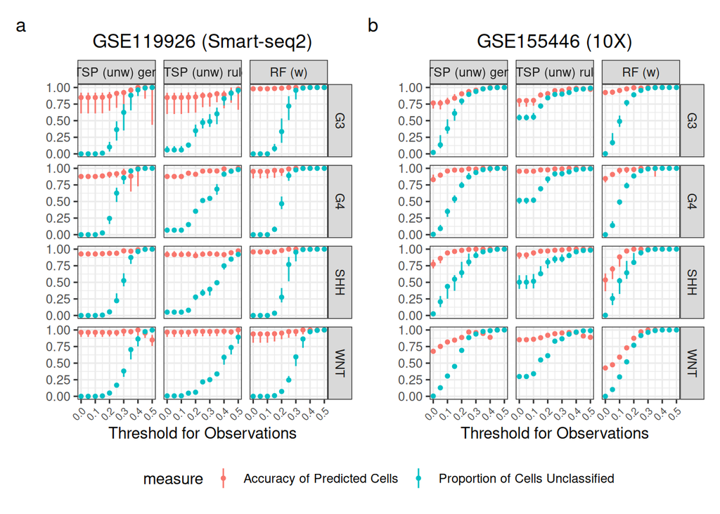

```r
# Smart-seq2 experiment
smartseq_object <- per_sample_stats_df |>
  dplyr::filter(study == "GSE119926",
                subgroup %in% mb_subgroups) |>
  ggplot(
    aes(
      x = prop_observed,
      y = value,
      group = measure,
      color = measure
    )
  ) +
  stat_summary(geom = "pointrange",
               fun = median,
               fun.max = \(x) quantile(x, 0.75),
               fun.min = \(x) quantile(x, 0.25),
               size = 0.1)+
  facet_grid(rows = vars(subgroup),
             cols = vars(strategy)) +
  labs(title = "GSE119926 (Smart-seq2)",
       x = "Threshold for Observations",
       y = "") +
  theme_bw() +
  theme(plot.title = element_text(hjust = 0.5),
        axis.text.x = element_text(angle = 45, vjust = 1, hjust = 1, size = 7))

# 10X Genomics Experiment
tenx_object <- per_sample_stats_df |>
  dplyr::filter(study == "GSE155446",
                subgroup %in% mb_subgroups) |>
  ggplot(
    aes(
      x = prop_observed,
      y = value,
      group = measure,
      color = measure
    )
  ) +
  stat_summary(geom = "pointrange",
               fun = median,
               fun.max = \(x) quantile(x, 0.75),
               fun.min = \(x) quantile(x, 0.25),
               size = 0.1) +
  facet_grid(rows = vars(subgroup),
             cols = vars(strategy)) +
  labs(title = "GSE155446 (10X)",
       x = "Threshold for Observations",
       y = "") +
  theme_bw() +
  theme(plot.title = element_text(hjust = 0.5),
        axis.text.x = element_text(angle = 45, vjust = 1, hjust = 1, size = 7))

combined_stats_plot <- smartseq_object + tenx_object +
  plot_annotation(tag_levels = "a") +
  plot_layout(guides = "collect") &
  theme(legend.position = "bottom")

combined_stats_plot
```

```r
ggsave(plot = combined_stats_plot,
       filename = pointrange_plot_file,
       height = 8.5,
       width = 11,
       units = "in")
```

### Stacked bar plot of labels

Let’s make plots that look at the percent of cells in a sample classified with each label. For the Smart-seq2 dataset, let’s use values that represent *filtering > 0* (at least one gene is observed), since it doesn’t seem to matter very much. For the 10X dataset, let’s pick `prop_observed == 0.1` and gene filtering strategy for kTSP, which seems to be somewhat balanced between making improvements in accuracy and having many unclassified cells. We’ll display filter > 0 for the 10X dataset as a matter of comparison as well.

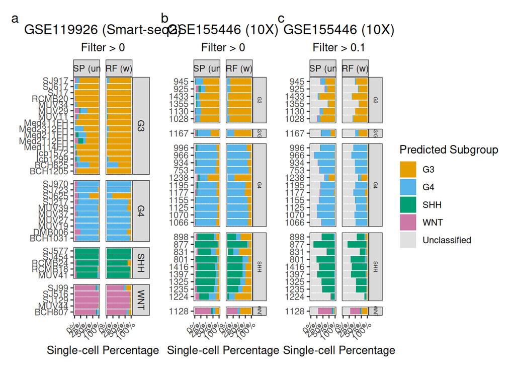

```r
# No filtering for Smart-seq2
smartseq_df <- results_df |>
  dplyr::filter(study == "GSE119926",
                prop_observed == 0,
                model_type == "RF (w)" |
                  model_type == "kTSP (unw)" & filtering_type == "gene")
smartseq_stacked_object <- smartseq_df |>
  make_stacked_labels_plot(plot_title = "GSE119926 (Smart-seq2)",
                           plot_subtitle = "Filter > 0") +
  theme(legend.position = "none")

# No filtering for 10X dataset
tenx_unfiltered_df <- results_df |>
  dplyr::filter(study == "GSE155446",
                prop_observed == 0,
                model_type == "RF (w)" |
                  model_type == "kTSP (unw)" & filtering_type == "gene")
tenx_unfiltered_stacked_object <- tenx_unfiltered_df |>
  make_stacked_labels_plot(plot_title = "GSE155446 (10X)",
                           plot_subtitle = "Filter > 0") +
  theme(legend.position = "none",
        strip.text.y = element_text(size = 5))

# Prop_observed == 0.1 and gene filtering for kTSP for 10x dataset
tenx_filtered_df <- results_df |>
  dplyr::filter(study == "GSE155446",
                prop_observed == 0.1,
                model_type == "RF (w)" |
                  model_type == "kTSP (unw)" & filtering_type == "gene")
tenx_filtered_stacked_object <- tenx_filtered_df |>
  make_stacked_labels_plot(plot_title = "GSE155446 (10X)",
                           plot_subtitle = "Filter > 0.1") +
  theme(strip.text.y = element_text(size = 5))

combined_stacked_plot <- smartseq_stacked_object +
  tenx_unfiltered_stacked_object +
  tenx_filtered_stacked_object +
  plot_annotation(tag_levels = "a")

combined_stacked_plot
```

This plot is consistent with what we would expect based on the last one – the Smart-seq2 predictions are very “accurate” regardless of model, and the RF classifier struggles with SHH and WNT in the 10X dataset.

```r
ggsave(plot = combined_stacked_plot,
       filename = stacked_plot_file,
       height = 8.5,
       width = 11,
       units = "in")
```

Save the underlying data to `plots/data`.

```r
stacked_barplot_df <- dplyr::bind_rows(
  smartseq_df,
  tenx_unfiltered_df,
  tenx_filtered_df
)
readr::write_tsv(stacked_barplot_df, file = individual_cell_results_file)
```